# R Notebook

```r
library(tidyverse)
library(caret)
library(fastDummies)
library(leaps)
```

```r
onlineCourses <- read.csv("https://raw.githubusercontent.com/reisanar/datasets/master/harvardMIT.csv")
```

```r
onlineCourses2 <- onlineCourses %>% dummy_cols(select_columns = "Course.Subject")
onlineCourses2
```

| Institution | Course.Number | Launch.Date | Course.Title | Instructors | Course.Subject | Year | Honor.Code.Certificates | Participants..Course.Content.Accessed. | Audited....50..Course.Content.Accessed. | Certified | X..Audited | X..Certified | X..Certified.of...50..Course.Content.Accessed | X..Played.Video | X..Posted.in.Forum | X..Grade.Higher.Than.Zero | Total.Course.Hours..Thousands. | Median.Hours.for.Certification | Median.Age | X..Male | X..Female | X..Bachelor.s.Degree.or.Higher | Course.Subject_Computer Science | Course.Subject_Government, Health, and Social Science | Course.Subject_Humanities, History, Design, Religion, and Education | Course.Subject_Science, Technology, Engineering, and Mathematics |
| --- | --- | --- | --- | --- | --- | --- | --- | --- | --- | --- | --- | --- | --- | --- | --- | --- | --- | --- | --- | --- | --- | --- | --- | --- | --- | --- |
| MITx | 6.002x | 09/05/2012 | Circuits and Electronics | Khurram Afridi | Science, Technology, Engineering, and Mathematics | 1 | 1 | 36105 | 5431 | 3003 | 15.04 | 8.32 | 54.98 | 83.2 | 8.17 | 28.97 | 418.94 | 64.45 | 26.0 | 88.28 | 11.72 | 60.68 | 0 | 0 | 0 | 1 |
| MITx | 6.00x | 09/26/2012 | Introduction to Computer Science and Programming | Eric Grimson, John Guttag, Chris Terman | Computer Science | 1 | 1 | 62709 | 8949 | 5783 | 14.27 | 9.22 | 64.05 | 89.14 | 14.38 | 39.50 | 884.04 | 78.53 | 28.0 | 83.50 | 16.50 | 63.04 | 1 | 0 | 0 | 0 |
| MITx | 3.091x | 10/09/2012 | Introduction to Solid State Chemistry | Michael Cima | Science, Technology, Engineering, and Mathematics | 1 | 1 | 16663 | 2855 | 2082 | 17.13 | 12.49 | 72.85 | 87.49 | 14.42 | 34.89 | 227.55 | 61.28 | 27.0 | 70.32 | 29.68 | 58.76 | 0 | 0 | 0 | 1 |
| HarvardX | CS50x | 10/15/2012 | Introduction to Computer Science | David Malan, Nate Hardison, Rob Bowden, Tommy MacWilliam, Zamyla Chan | Computer Science | 1 | 1 | 129400 | 12888 | 1439 | 9.96 | 1.11 | 11.11 | 0 | 0.00 | 1.11 | 220.90 | 0.00 | 28.0 | 80.02 | 19.98 | 58.78 | 1 | 0 | 0 | 0 |
| HarvardX | PH207x | 10/15/2012 | Health in Numbers: Quantitative Methods in Clinical and Public Health Research | Earl Francis Cook, Marcello Pagano | Government, Health, and Social Science | 1 | 1 | 52521 | 10729 | 5058 | 20.44 | 9.64 | 47.12 | 77.45 | 15.98 | 32.52 | 804.41 | 76.10 | 32.0 | 56.78 | 43.22 | 88.33 | 0 | 1 | 0 | 0 |
| MITx | 6.00x | 02/04/2013 | Introduction to Computer Science and Programming | Larry Rudolph | Computer Science | 1 | 1 | 65380 | 6473 | 3313 | 9.90 | 5.07 | 51.17 | 82.43 | 10.30 | 28.90 | 639.40 | 84.14 | 27.0 | 83.99 | 16.01 | 60.90 | 1 | 0 | 0 | 0 |
| MITx | 3.091x | 02/05/2013 | Introduction to Solid State Chemistry | Michael Cima | Science, Technology, Engineering, and Mathematics | 1 | 1 | 8270 | 838 | 547 | 10.13 | 6.61 | 65.16 | 80.25 | 10.22 | 23.49 | 68.11 | 59.29 | 27.0 | 73.30 | 26.70 | 58.99 | 0 | 0 | 0 | 1 |
| MITx | 14.73x | 02/12/2013 | The Challenges of Global Poverty | Esther Duflo, Abhijit Banerjee | Government, Health, and Social Science | 1 | 1 | 29044 | 6510 | 4607 | 22.41 | 15.86 | 70.60 | 83.24 | 13.89 | 39.38 | 279.22 | 40.30 | 30.0 | 53.76 | 46.24 | 81.94 | 0 | 1 | 0 | 0 |
| MITx | 8.02x | 02/18/2013 | Electricity and Magnetism | Walter Lewin, John Belcher, Peter Dourmashkin, Ricardo Abbate, Saif Rayyan, George Stephans, Isaac Chuang | Science, Technology, Engineering, and Mathematics | 1 | 1 | 39178 | 3543 | 1722 | 9.04 | 4.40 | 48.49 | 85.3 | 5.86 | 16.04 | 380.35 | 107.88 | 26.0 | 85.42 | 14.58 | 56.97 | 0 | 0 | 0 | 1 |
| HarvardX | ER22x | 03/02/2013 | Justice | Michael Sandel | Humanities, History, Design, Religion, and Education | 1 | 1 | 58779 | 9425 | 5438 | 16.05 | 9.26 | 51.07 | --- | 21.86 | 20.98 | 186.61 | 13.67 | 30.0 | 60.42 | 39.58 | 69.78 | 0 | 0 | 1 | 0 |

[output cut: 280 more lines]

##Introduction

## Renaming Variables

```r
online_courses <- onlineCourses2 %>% rename(participants = Participants..Course.Content.Accessed., institution = Institution, course_number = Course.Number, launch_date = Launch.Date, course = Course.Title, instructors = Instructors, subject = Course.Subject, year = Year, honor_certificate = Honor.Code.Certificates, half_completed =
Audited....50..Course.Content.Accessed., completed = Certified, completed_ratio = X..Certified, half_completed_ratio =
X..Audited, completed_given_half_ratio = X..Certified.of...50..Course.Content.Accessed, played_video_ratio = X..Played.Video, posted_forum_ratio = X..Posted.in.Forum, grade_above_zero = X..Grade.Higher.Than.Zero, course_hours = Total.Course.Hours..Thousands., hours_certification_median = Median.Hours.for.Certification, age_median = Median.Age, male_ratio = X..Male, female_ratio = X..Female, bachelor_ratio = X..Bachelor.s.Degree.or.Higher, subject_cs =  "Course.Subject_Computer Science", subject_gov = "Course.Subject_Government, Health, and Social Science", subject_hum = "Course.Subject_Humanities, History, Design, Religion, and Education", subject_stem = "Course.Subject_Science, Technology, Engineering, and Mathematics") %>%
  mutate(ln_participants = log(participants), ln_completed_ratio = log(completed_ratio))
online_courses
```

| institution | course_number | launch_date | course | instructors | subject | year | honor_certificate | participants | half_completed | completed | half_completed_ratio | completed_ratio | completed_given_half_ratio | played_video_ratio | posted_forum_ratio | grade_above_zero | course_hours | hours_certification_median | age_median | male_ratio | female_ratio | bachelor_ratio | subject_cs | subject_gov | subject_hum | subject_stem | ln_participants | ln_completed_ratio |
| --- | --- | --- | --- | --- | --- | --- | --- | --- | --- | --- | --- | --- | --- | --- | --- | --- | --- | --- | --- | --- | --- | --- | --- | --- | --- | --- | --- | --- |
| MITx | 6.002x | 09/05/2012 | Circuits and Electronics | Khurram Afridi | Science, Technology, Engineering, and Mathematics | 1 | 1 | 36105 | 5431 | 3003 | 15.04 | 8.32 | 54.98 | 83.2 | 8.17 | 28.97 | 418.94 | 64.45 | 26.0 | 88.28 | 11.72 | 60.68 | 0 | 0 | 0 | 1 | 10.494187 | 2.11866225 |
| MITx | 6.00x | 09/26/2012 | Introduction to Computer Science and Programming | Eric Grimson, John Guttag, Chris Terman | Computer Science | 1 | 1 | 62709 | 8949 | 5783 | 14.27 | 9.22 | 64.05 | 89.14 | 14.38 | 39.50 | 884.04 | 78.53 | 28.0 | 83.50 | 16.50 | 63.04 | 1 | 0 | 0 | 0 | 11.046260 | 2.22137504 |
| MITx | 3.091x | 10/09/2012 | Introduction to Solid State Chemistry | Michael Cima | Science, Technology, Engineering, and Mathematics | 1 | 1 | 16663 | 2855 | 2082 | 17.13 | 12.49 | 72.85 | 87.49 | 14.42 | 34.89 | 227.55 | 61.28 | 27.0 | 70.32 | 29.68 | 58.76 | 0 | 0 | 0 | 1 | 9.720946 | 2.52492832 |
| HarvardX | CS50x | 10/15/2012 | Introduction to Computer Science | David Malan, Nate Hardison, Rob Bowden, Tommy MacWilliam, Zamyla Chan | Computer Science | 1 | 1 | 129400 | 12888 | 1439 | 9.96 | 1.11 | 11.11 | 0 | 0.00 | 1.11 | 220.90 | 0.00 | 28.0 | 80.02 | 19.98 | 58.78 | 1 | 0 | 0 | 0 | 11.770664 | 0.10436002 |
| HarvardX | PH207x | 10/15/2012 | Health in Numbers: Quantitative Methods in Clinical and Public Health Research | Earl Francis Cook, Marcello Pagano | Government, Health, and Social Science | 1 | 1 | 52521 | 10729 | 5058 | 20.44 | 9.64 | 47.12 | 77.45 | 15.98 | 32.52 | 804.41 | 76.10 | 32.0 | 56.78 | 43.22 | 88.33 | 0 | 1 | 0 | 0 | 10.868968 | 2.26592111 |
| MITx | 6.00x | 02/04/2013 | Introduction to Computer Science and Programming | Larry Rudolph | Computer Science | 1 | 1 | 65380 | 6473 | 3313 | 9.90 | 5.07 | 51.17 | 82.43 | 10.30 | 28.90 | 639.40 | 84.14 | 27.0 | 83.99 | 16.01 | 60.90 | 1 | 0 | 0 | 0 | 11.087972 | 1.62334082 |
| MITx | 3.091x | 02/05/2013 | Introduction to Solid State Chemistry | Michael Cima | Science, Technology, Engineering, and Mathematics | 1 | 1 | 8270 | 838 | 547 | 10.13 | 6.61 | 65.16 | 80.25 | 10.22 | 23.49 | 68.11 | 59.29 | 27.0 | 73.30 | 26.70 | 58.99 | 0 | 0 | 0 | 1 | 9.020390 | 1.88858365 |
| MITx | 14.73x | 02/12/2013 | The Challenges of Global Poverty | Esther Duflo, Abhijit Banerjee | Government, Health, and Social Science | 1 | 1 | 29044 | 6510 | 4607 | 22.41 | 15.86 | 70.60 | 83.24 | 13.89 | 39.38 | 279.22 | 40.30 | 30.0 | 53.76 | 46.24 | 81.94 | 0 | 1 | 0 | 0 | 10.276567 | 2.76380022 |
| MITx | 8.02x | 02/18/2013 | Electricity and Magnetism | Walter Lewin, John Belcher, Peter Dourmashkin, Ricardo Abbate, Saif Rayyan, George Stephans, Isaac Chuang | Science, Technology, Engineering, and Mathematics | 1 | 1 | 39178 | 3543 | 1722 | 9.04 | 4.40 | 48.49 | 85.3 | 5.86 | 16.04 | 380.35 | 107.88 | 26.0 | 85.42 | 14.58 | 56.97 | 0 | 0 | 0 | 1 | 10.575871 | 1.48160454 |
| HarvardX | ER22x | 03/02/2013 | Justice | Michael Sandel | Humanities, History, Design, Religion, and Education | 1 | 1 | 58779 | 9425 | 5438 | 16.05 | 9.26 | 51.07 | --- | 21.86 | 20.98 | 186.61 | 13.67 | 30.0 | 60.42 | 39.58 | 69.78 | 0 | 0 | 1 | 0 | 10.981540 | 2.22570405 |

[output cut: 280 more lines]

**Transforming Inf value into NA**

```r
cf_DFinf2NA <- function(x)
{
    for (i in 1:ncol(x)){
          x[,i][is.infinite(x[,i])] = NA
    }
    return(x)
}
online_courses <- cf_DFinf2NA(online_courses)
online_courses
```

| institution | course_number | launch_date | course | instructors | subject | year | honor_certificate | participants | half_completed | completed | half_completed_ratio | completed_ratio | completed_given_half_ratio | played_video_ratio | posted_forum_ratio | grade_above_zero | course_hours | hours_certification_median | age_median | male_ratio | female_ratio | bachelor_ratio | subject_cs | subject_gov | subject_hum | subject_stem | ln_participants | ln_completed_ratio |
| --- | --- | --- | --- | --- | --- | --- | --- | --- | --- | --- | --- | --- | --- | --- | --- | --- | --- | --- | --- | --- | --- | --- | --- | --- | --- | --- | --- | --- |
| MITx | 6.002x | 09/05/2012 | Circuits and Electronics | Khurram Afridi | Science, Technology, Engineering, and Mathematics | 1 | 1 | 36105 | 5431 | 3003 | 15.04 | 8.32 | 54.98 | 83.2 | 8.17 | 28.97 | 418.94 | 64.45 | 26.0 | 88.28 | 11.72 | 60.68 | 0 | 0 | 0 | 1 | 10.494187 | 2.11866225 |
| MITx | 6.00x | 09/26/2012 | Introduction to Computer Science and Programming | Eric Grimson, John Guttag, Chris Terman | Computer Science | 1 | 1 | 62709 | 8949 | 5783 | 14.27 | 9.22 | 64.05 | 89.14 | 14.38 | 39.50 | 884.04 | 78.53 | 28.0 | 83.50 | 16.50 | 63.04 | 1 | 0 | 0 | 0 | 11.046260 | 2.22137504 |
| MITx | 3.091x | 10/09/2012 | Introduction to Solid State Chemistry | Michael Cima | Science, Technology, Engineering, and Mathematics | 1 | 1 | 16663 | 2855 | 2082 | 17.13 | 12.49 | 72.85 | 87.49 | 14.42 | 34.89 | 227.55 | 61.28 | 27.0 | 70.32 | 29.68 | 58.76 | 0 | 0 | 0 | 1 | 9.720946 | 2.52492832 |
| HarvardX | CS50x | 10/15/2012 | Introduction to Computer Science | David Malan, Nate Hardison, Rob Bowden, Tommy MacWilliam, Zamyla Chan | Computer Science | 1 | 1 | 129400 | 12888 | 1439 | 9.96 | 1.11 | 11.11 | 0 | 0.00 | 1.11 | 220.90 | 0.00 | 28.0 | 80.02 | 19.98 | 58.78 | 1 | 0 | 0 | 0 | 11.770664 | 0.10436002 |
| HarvardX | PH207x | 10/15/2012 | Health in Numbers: Quantitative Methods in Clinical and Public Health Research | Earl Francis Cook, Marcello Pagano | Government, Health, and Social Science | 1 | 1 | 52521 | 10729 | 5058 | 20.44 | 9.64 | 47.12 | 77.45 | 15.98 | 32.52 | 804.41 | 76.10 | 32.0 | 56.78 | 43.22 | 88.33 | 0 | 1 | 0 | 0 | 10.868968 | 2.26592111 |
| MITx | 6.00x | 02/04/2013 | Introduction to Computer Science and Programming | Larry Rudolph | Computer Science | 1 | 1 | 65380 | 6473 | 3313 | 9.90 | 5.07 | 51.17 | 82.43 | 10.30 | 28.90 | 639.40 | 84.14 | 27.0 | 83.99 | 16.01 | 60.90 | 1 | 0 | 0 | 0 | 11.087972 | 1.62334082 |
| MITx | 3.091x | 02/05/2013 | Introduction to Solid State Chemistry | Michael Cima | Science, Technology, Engineering, and Mathematics | 1 | 1 | 8270 | 838 | 547 | 10.13 | 6.61 | 65.16 | 80.25 | 10.22 | 23.49 | 68.11 | 59.29 | 27.0 | 73.30 | 26.70 | 58.99 | 0 | 0 | 0 | 1 | 9.020390 | 1.88858365 |
| MITx | 14.73x | 02/12/2013 | The Challenges of Global Poverty | Esther Duflo, Abhijit Banerjee | Government, Health, and Social Science | 1 | 1 | 29044 | 6510 | 4607 | 22.41 | 15.86 | 70.60 | 83.24 | 13.89 | 39.38 | 279.22 | 40.30 | 30.0 | 53.76 | 46.24 | 81.94 | 0 | 1 | 0 | 0 | 10.276567 | 2.76380022 |
| MITx | 8.02x | 02/18/2013 | Electricity and Magnetism | Walter Lewin, John Belcher, Peter Dourmashkin, Ricardo Abbate, Saif Rayyan, George Stephans, Isaac Chuang | Science, Technology, Engineering, and Mathematics | 1 | 1 | 39178 | 3543 | 1722 | 9.04 | 4.40 | 48.49 | 85.3 | 5.86 | 16.04 | 380.35 | 107.88 | 26.0 | 85.42 | 14.58 | 56.97 | 0 | 0 | 0 | 1 | 10.575871 | 1.48160454 |
| HarvardX | ER22x | 03/02/2013 | Justice | Michael Sandel | Humanities, History, Design, Religion, and Education | 1 | 1 | 58779 | 9425 | 5438 | 16.05 | 9.26 | 51.07 | --- | 21.86 | 20.98 | 186.61 | 13.67 | 30.0 | 60.42 | 39.58 | 69.78 | 0 | 0 | 1 | 0 | 10.981540 | 2.22570405 |

[output cut: 280 more lines]

##Data Dictionary

**Important information related to the data:**

- The log transformed variable for course participants is approximately normal
- The log transformed variable for completed ratio is closer to a normal distribution than the original variable.

**EDA**

```r
online_courses %>%
  group_by(year) %>%
  summarize(average_certified = mean(completed_ratio),sd_certified_ratio = sd(completed_ratio))
```

| year | average_certified | sd_certified_ratio |
| --- | --- | --- |
| 1 | 8.328750 | 3.608320 |
| 2 | 8.337200 | 7.721826 |
| 3 | 8.786196 | 7.695650 |
| 4 | 6.806818 | 6.363602 |

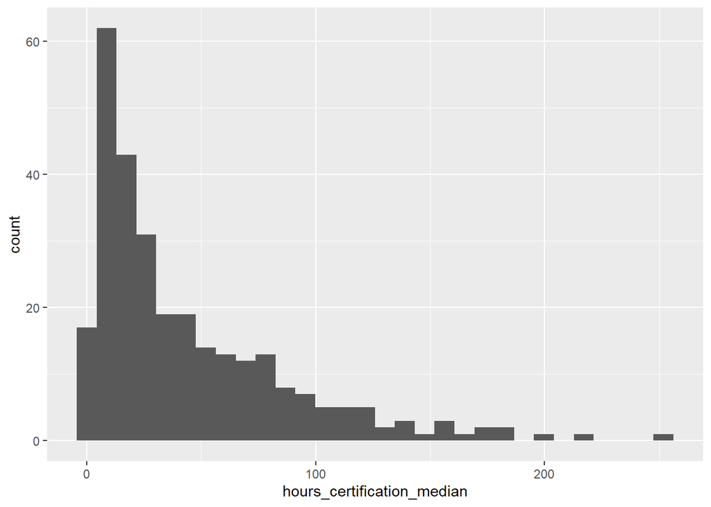

```r
ggplot(data=online_courses) + geom_histogram(mapping = aes(x = hours_certification_median))
```

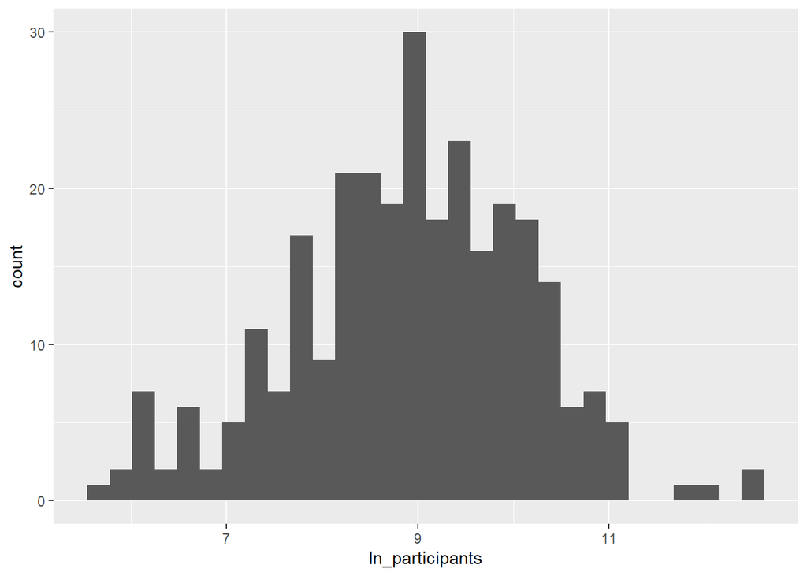

```r
ggplot(data=online_courses) + geom_histogram(mapping = aes(x = ln_participants))
```

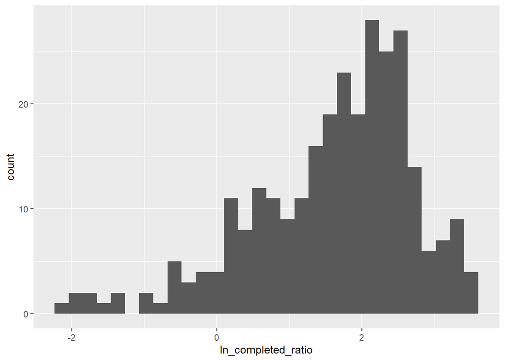

```r
ggplot(data=online_courses) + geom_histogram(mapping = aes(x = ln_completed_ratio))
```

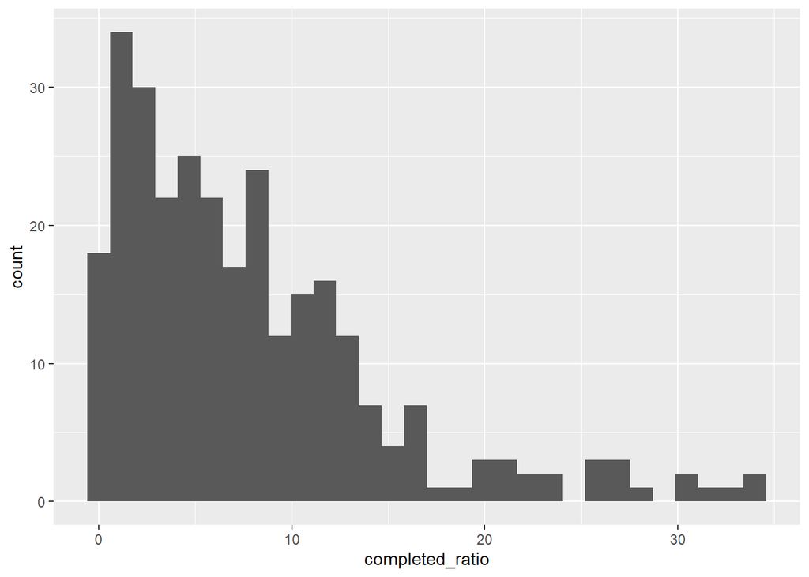

```r
ggplot(data=online_courses) + geom_histogram(mapping = aes(x = completed_ratio))
```

```r
online_courses_shrinked <- online_courses %>% select(institution, subject, year, ln_participants, half_completed, half_completed_ratio, completed_ratio, grade_above_zero, course_hours, bachelor_ratio, hours_certification_median, age_median, subject_cs, subject_gov, subject_hum, subject_stem)
online_courses_shrinked
```

| institution | subject | year | ln_participants | half_completed | half_completed_ratio | completed_ratio | grade_above_zero | course_hours | bachelor_ratio | hours_certification_median | age_median | subject_cs | subject_gov | subject_hum | subject_stem |
| --- | --- | --- | --- | --- | --- | --- | --- | --- | --- | --- | --- | --- | --- | --- | --- |
| MITx | Science, Technology, Engineering, and Mathematics | 1 | 10.494187 | 5431 | 15.04 | 8.32 | 28.97 | 418.94 | 60.68 | 64.45 | 26.0 | 0 | 0 | 0 | 1 |
| MITx | Computer Science | 1 | 11.046260 | 8949 | 14.27 | 9.22 | 39.50 | 884.04 | 63.04 | 78.53 | 28.0 | 1 | 0 | 0 | 0 |
| MITx | Science, Technology, Engineering, and Mathematics | 1 | 9.720946 | 2855 | 17.13 | 12.49 | 34.89 | 227.55 | 58.76 | 61.28 | 27.0 | 0 | 0 | 0 | 1 |
| HarvardX | Computer Science | 1 | 11.770664 | 12888 | 9.96 | 1.11 | 1.11 | 220.90 | 58.78 | 0.00 | 28.0 | 1 | 0 | 0 | 0 |
| HarvardX | Government, Health, and Social Science | 1 | 10.868968 | 10729 | 20.44 | 9.64 | 32.52 | 804.41 | 88.33 | 76.10 | 32.0 | 0 | 1 | 0 | 0 |
| MITx | Computer Science | 1 | 11.087972 | 6473 | 9.90 | 5.07 | 28.90 | 639.40 | 60.90 | 84.14 | 27.0 | 1 | 0 | 0 | 0 |
| MITx | Science, Technology, Engineering, and Mathematics | 1 | 9.020390 | 838 | 10.13 | 6.61 | 23.49 | 68.11 | 58.99 | 59.29 | 27.0 | 0 | 0 | 0 | 1 |
| MITx | Government, Health, and Social Science | 1 | 10.276567 | 6510 | 22.41 | 15.86 | 39.38 | 279.22 | 81.94 | 40.30 | 30.0 | 0 | 1 | 0 | 0 |
| MITx | Science, Technology, Engineering, and Mathematics | 1 | 10.575871 | 3543 | 9.04 | 4.40 | 16.04 | 380.35 | 56.97 | 107.88 | 26.0 | 0 | 0 | 0 | 1 |
| HarvardX | Humanities, History, Design, Religion, and Education | 1 | 10.981540 | 9425 | 16.05 | 9.26 | 20.98 | 186.61 | 69.78 | 13.67 | 30.0 | 0 | 0 | 1 | 0 |

[output cut: 280 more lines]

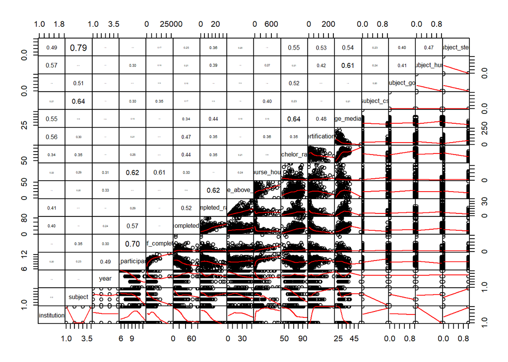

```r
panel.cor <- function(x, y, digits = 2, prefix = "", cex.cor, ...)
{
    usr <- par("usr"); on.exit(par(usr))
    par(usr = c(0, 1, 0, 1))
    r <- abs(cor(x, y))
    txt <- format(c(r, 0.123456789), digits = digits)[1]
    txt <- paste0(prefix, txt)
    if(missing(cex.cor)) cex.cor <- 0.8/strwidth(txt)
    text(0.5, 0.5, txt, cex = cex.cor * r)
}

pairs(online_courses_shrinked, lower.panel = panel.smooth, upper.panel = panel.cor,
      gap=0, row1attop=FALSE)
```

##Exploring correlation between variables

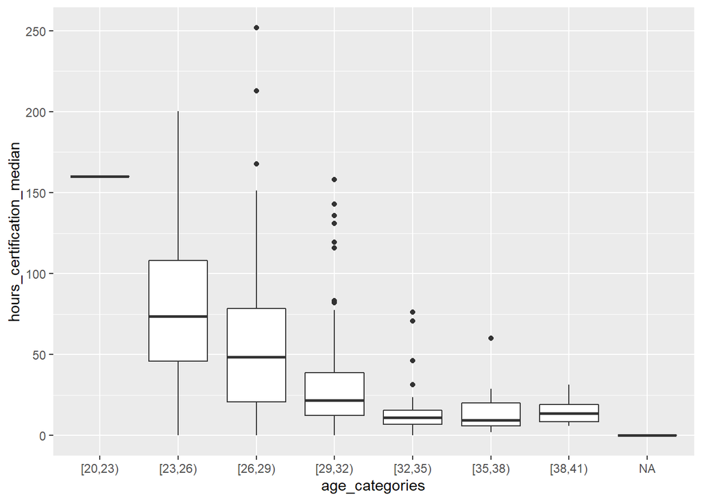

```r
online_courses %>% mutate(age_categories = cut(age_median, seq(20,55,3), right=FALSE)) %>%  ggplot() + geom_boxplot(aes(x=age_categories, y=hours_certification_median))
```

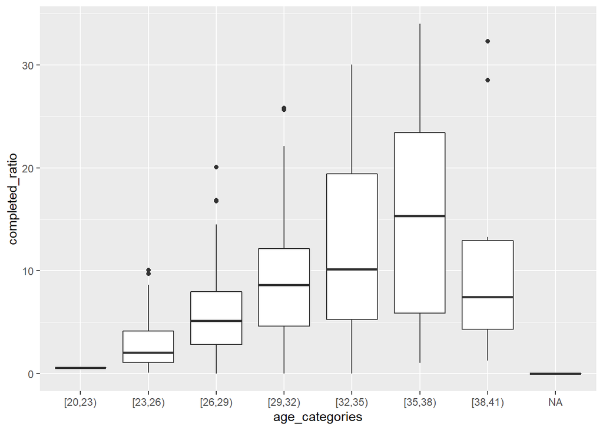

```r
online_courses %>% mutate(age_categories = cut(age_median, seq(20,55,3), right=FALSE)) %>%  ggplot() + geom_boxplot(aes(x=age_categories, y=completed_ratio))
```

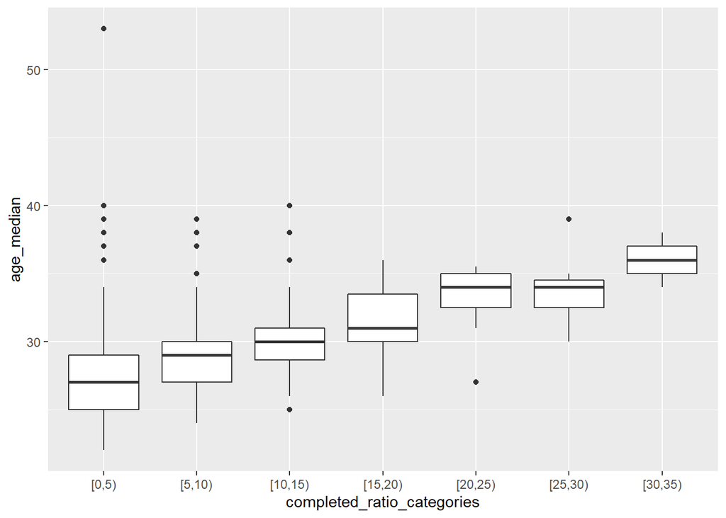

```r
online_courses %>% mutate(completed_ratio_categories = cut(completed_ratio, seq(0,100,5), right=FALSE)) %>%  ggplot() + geom_boxplot(aes(x=completed_ratio_categories, y=age_median))
```

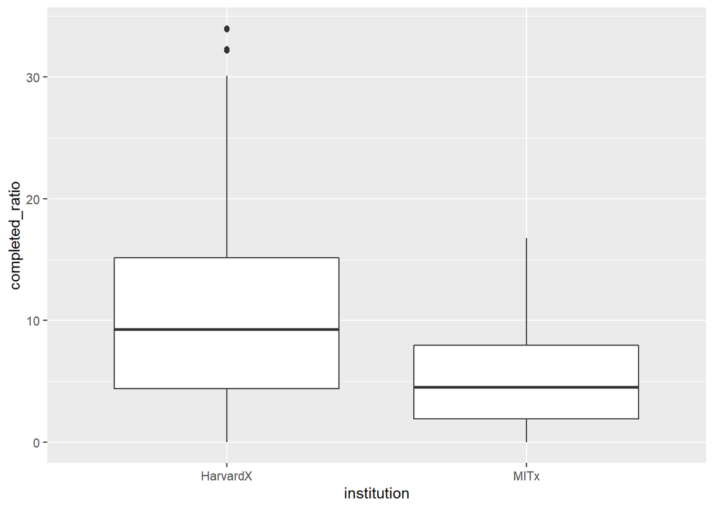

```r
online_courses %>%  ggplot() + geom_boxplot(aes(x=institution, y=completed_ratio))
```

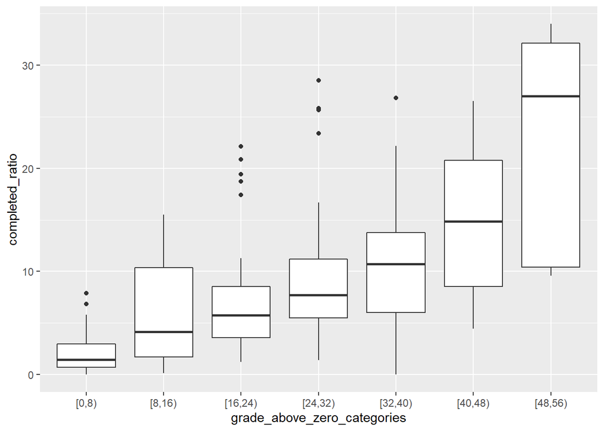

```r
online_courses %>% mutate(grade_above_zero_categories = cut(grade_above_zero, seq(0,56,8), right=FALSE)) %>% ggplot() + geom_boxplot(aes(x=grade_above_zero_categories, y=completed_ratio))
```

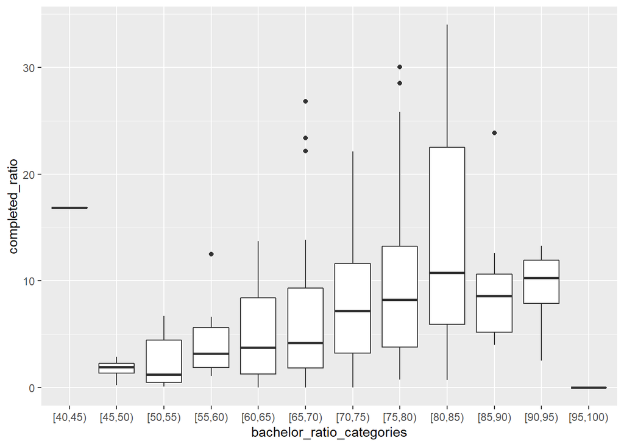

```r
online_courses %>% mutate(bachelor_ratio_categories = cut(bachelor_ratio, seq(40,100,5), right=FALSE)) %>%  ggplot() + geom_boxplot(aes(x=bachelor_ratio_categories, y=completed_ratio))
```

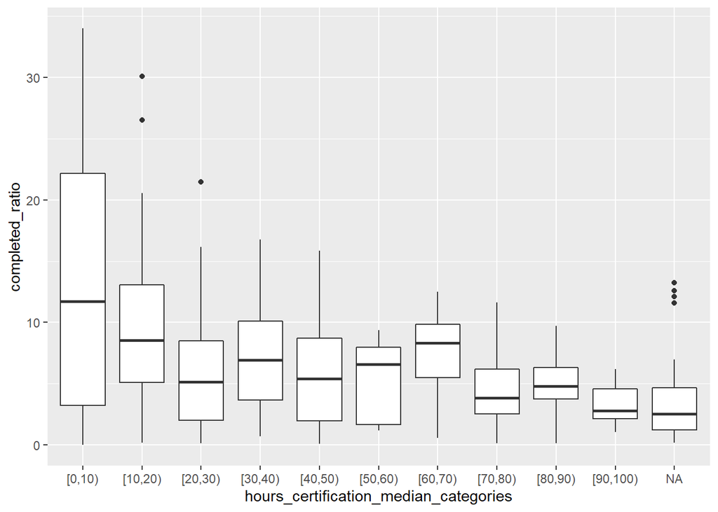

```r
online_courses %>% mutate(hours_certification_median_categories = cut(hours_certification_median, seq(0,100,10), right=FALSE)) %>%  ggplot() + geom_boxplot(aes(x=hours_certification_median_categories, y=completed_ratio))
```

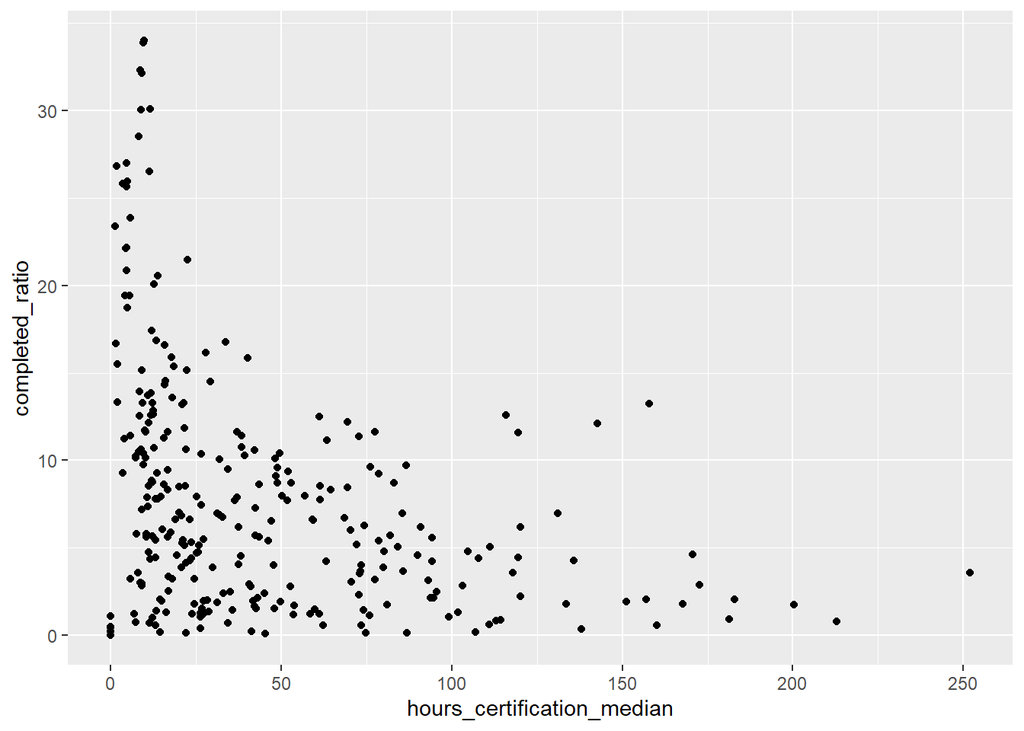

```r
online_courses %>%  ggplot() + geom_point(aes(x=hours_certification_median, y=completed_ratio))
```

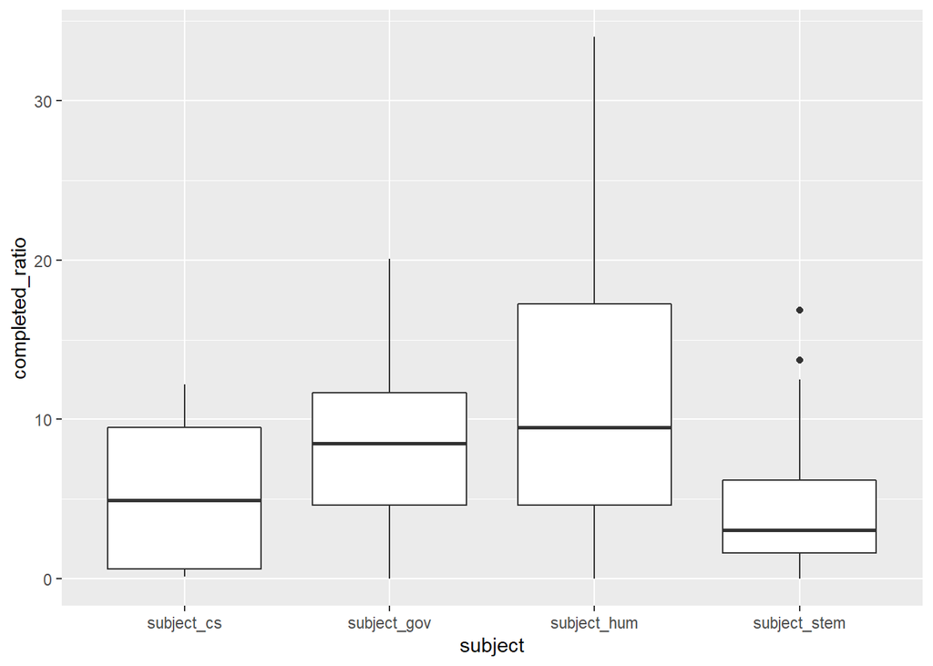

```r
online_courses %>% gather(subject_cs, subject_gov, subject_hum, subject_stem, key = "subject", value = "boolean_auxiliar") %>% filter(boolean_auxiliar == 1) %>% ggplot() + geom_boxplot(aes(x=subject, y=completed_ratio))
```

## Linear Models

**Filtering NA values**

```r
lm_online_data <- online_courses %>% filter(!is.na(ln_completed_ratio))
lm_online_data
```

| institution | course_number | launch_date | course | instructors | subject | year | honor_certificate | participants | half_completed | completed | half_completed_ratio | completed_ratio | completed_given_half_ratio | played_video_ratio | posted_forum_ratio | grade_above_zero | course_hours | hours_certification_median | age_median | male_ratio | female_ratio | bachelor_ratio | subject_cs | subject_gov | subject_hum | subject_stem | ln_participants | ln_completed_ratio |
| --- | --- | --- | --- | --- | --- | --- | --- | --- | --- | --- | --- | --- | --- | --- | --- | --- | --- | --- | --- | --- | --- | --- | --- | --- | --- | --- | --- | --- |
| MITx | 6.002x | 09/05/2012 | Circuits and Electronics | Khurram Afridi | Science, Technology, Engineering, and Mathematics | 1 | 1 | 36105 | 5431 | 3003 | 15.04 | 8.32 | 54.98 | 83.2 | 8.17 | 28.97 | 418.94 | 64.45 | 26.0 | 88.28 | 11.72 | 60.68 | 0 | 0 | 0 | 1 | 10.494187 | 2.11866225 |
| MITx | 6.00x | 09/26/2012 | Introduction to Computer Science and Programming | Eric Grimson, John Guttag, Chris Terman | Computer Science | 1 | 1 | 62709 | 8949 | 5783 | 14.27 | 9.22 | 64.05 | 89.14 | 14.38 | 39.50 | 884.04 | 78.53 | 28.0 | 83.50 | 16.50 | 63.04 | 1 | 0 | 0 | 0 | 11.046260 | 2.22137504 |
| MITx | 3.091x | 10/09/2012 | Introduction to Solid State Chemistry | Michael Cima | Science, Technology, Engineering, and Mathematics | 1 | 1 | 16663 | 2855 | 2082 | 17.13 | 12.49 | 72.85 | 87.49 | 14.42 | 34.89 | 227.55 | 61.28 | 27.0 | 70.32 | 29.68 | 58.76 | 0 | 0 | 0 | 1 | 9.720946 | 2.52492832 |
| HarvardX | CS50x | 10/15/2012 | Introduction to Computer Science | David Malan, Nate Hardison, Rob Bowden, Tommy MacWilliam, Zamyla Chan | Computer Science | 1 | 1 | 129400 | 12888 | 1439 | 9.96 | 1.11 | 11.11 | 0 | 0.00 | 1.11 | 220.90 | 0.00 | 28.0 | 80.02 | 19.98 | 58.78 | 1 | 0 | 0 | 0 | 11.770664 | 0.10436002 |
| HarvardX | PH207x | 10/15/2012 | Health in Numbers: Quantitative Methods in Clinical and Public Health Research | Earl Francis Cook, Marcello Pagano | Government, Health, and Social Science | 1 | 1 | 52521 | 10729 | 5058 | 20.44 | 9.64 | 47.12 | 77.45 | 15.98 | 32.52 | 804.41 | 76.10 | 32.0 | 56.78 | 43.22 | 88.33 | 0 | 1 | 0 | 0 | 10.868968 | 2.26592111 |
| MITx | 6.00x | 02/04/2013 | Introduction to Computer Science and Programming | Larry Rudolph | Computer Science | 1 | 1 | 65380 | 6473 | 3313 | 9.90 | 5.07 | 51.17 | 82.43 | 10.30 | 28.90 | 639.40 | 84.14 | 27.0 | 83.99 | 16.01 | 60.90 | 1 | 0 | 0 | 0 | 11.087972 | 1.62334082 |
| MITx | 3.091x | 02/05/2013 | Introduction to Solid State Chemistry | Michael Cima | Science, Technology, Engineering, and Mathematics | 1 | 1 | 8270 | 838 | 547 | 10.13 | 6.61 | 65.16 | 80.25 | 10.22 | 23.49 | 68.11 | 59.29 | 27.0 | 73.30 | 26.70 | 58.99 | 0 | 0 | 0 | 1 | 9.020390 | 1.88858365 |
| MITx | 14.73x | 02/12/2013 | The Challenges of Global Poverty | Esther Duflo, Abhijit Banerjee | Government, Health, and Social Science | 1 | 1 | 29044 | 6510 | 4607 | 22.41 | 15.86 | 70.60 | 83.24 | 13.89 | 39.38 | 279.22 | 40.30 | 30.0 | 53.76 | 46.24 | 81.94 | 0 | 1 | 0 | 0 | 10.276567 | 2.76380022 |
| MITx | 8.02x | 02/18/2013 | Electricity and Magnetism | Walter Lewin, John Belcher, Peter Dourmashkin, Ricardo Abbate, Saif Rayyan, George Stephans, Isaac Chuang | Science, Technology, Engineering, and Mathematics | 1 | 1 | 39178 | 3543 | 1722 | 9.04 | 4.40 | 48.49 | 85.3 | 5.86 | 16.04 | 380.35 | 107.88 | 26.0 | 85.42 | 14.58 | 56.97 | 0 | 0 | 0 | 1 | 10.575871 | 1.48160454 |
| HarvardX | ER22x | 03/02/2013 | Justice | Michael Sandel | Humanities, History, Design, Religion, and Education | 1 | 1 | 58779 | 9425 | 5438 | 16.05 | 9.26 | 51.07 | --- | 21.86 | 20.98 | 186.61 | 13.67 | 30.0 | 60.42 | 39.58 | 69.78 | 0 | 0 | 1 | 0 | 10.981540 | 2.22570405 |

[output cut: 276 more lines]

**Separating the data into Train and Test**

```r
set.seed(123)
train_control <-  trainControl(method = "cv", number = 10)
inTrain <- createDataPartition(y = lm_online_data$ln_completed_ratio, p = 0.7, list = FALSE)
train_set <- lm_online_data[inTrain , ]
test_set <- lm_online_data[-inTrain , ]
```

**Variables selection**

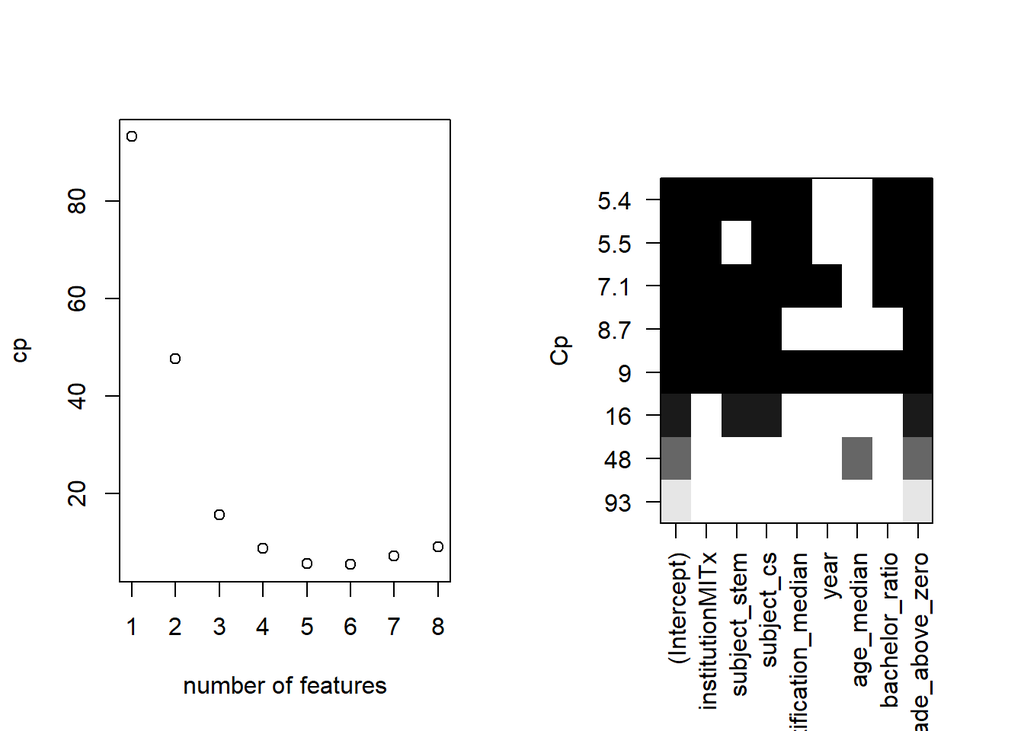

```r
#Separating the data
sub_fit_certified <- regsubsets(ln_completed_ratio ~ institution + subject_stem + subject_cs + hours_certification_median + year + age_median + bachelor_ratio + grade_above_zero , data = train_set)
best_summary <- summary(sub_fit_certified)

#Plots
par(mfrow = c(1,2))
plot(best_summary$cp, xlab = "number of features", ylab = "cp")
plot(sub_fit_certified, scale = "Cp")
```

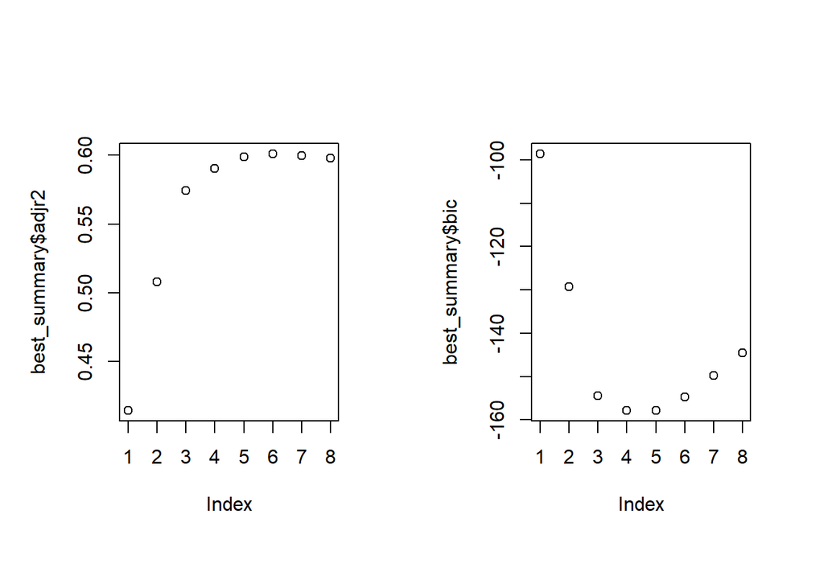

```r
par(mfrow = c(1,2))
plot(best_summary$adjr2)
plot(best_summary$bic)
```

##Modeling With other Techniques